# Tugas Pertama Praktikum Pemrograman Statistika

Author

Kandi Dwi Pratiwi

# NOMOR 1

Buatlah pseudocode dan flowchart untuk menentukan apakah sebuah bilangan bulat yang dimasukkan pengguna merupakan bilangan genap atau ganjil.

Adapun flowchart dan pseudocode untuk menentukan bilangan genap atau ganjil adalah sebagai berikut:

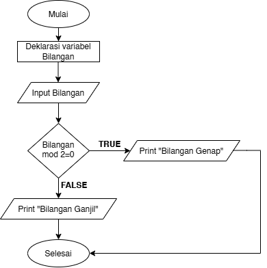

Gambar 1. Flowchart Penentuan Bilangan Genap Atau Ganjil

```
Mulai
Algoritma BilanganBulat
Deklarasi:
  Bilangan:integer positif
Deskripsi:
  Input:Bilangan
  IF (Bilangan mod 2=0) THEN
    Print "Bilangan Genap"
  ELSE
    Print "Bilangan Ganjil"
  END IF
Selesai
```

# NOMOR 2

Perhatikan algoritma berikut:

```
Mulai
Input panjang
Input lebar
luas <- panjang * lebar
keliling <- 2 * (panjang + lebar)
Output luas
Output keliling
Selesai
```

Jelaskan jenis struktur algoritma yang digunakan dan berikan alasannya.

```
Urutan algoritmanya dalam soal adalah sebagai berikut:
Mulai
Input panjang #user memasukkan nilai panjang
Input lebar #user memasukkan nilai lebar
luas <- panjang * lebar #menghitung luas persegi panjang
keliling <- 2 * (panjang + lebar) #menghitung keliling persegi panjang
Output luas #menampilkan nilai luas
Output keliling #menampilkan nilai keliling
Selesai
```

**Note**

Algoritma tersebut menggunakan struktur runtunan (sequence) karena setiap instruksi dijalankan secara berurutan dari langkah pertama hingga langkah terakhir, tanpa adanya percabangan (pemilihan kondisi) ataupun perulangan.

# NOMOR 3

Buatlah algoritma untuk menentukan kategori nilai mahasiswa dengan ketentuan:

- Nilai ≥ 80 → `"Baik"`
- Nilai 60–79 → `"Cukup"`
- Nilai < 60 → `"Kurang"`

Tuliskan algoritma tersebut dalam bentuk pseudocode.

```
Mulai
Algoritma KategoriNilaiSiswa
Deklarasi:
  Nilai:integer
  Kategori:string
Deskripsi:
  Input: Nilai
  IF Nilai>=80 THEN
    Kategori="Baik"
  ELSE IF Nilai>=60 AND Nilai<=79 THEN
    Kategori="Cukup"
  ELSE
    Kategori="Kurang"
  END IF
Output:Kategori
Selesai
```

# NOMOR 4

Buat sebuah vektor berisi bilangan genap dari 2 sampai 20. Hitung jumlah elemen dan rata-ratanya.

```r
#Membuat vector bil. genap dari 2 sampai 20
a<-seq(2,20,by=2)
print(a)
```

```
 [1]  2  4  6  8 10 12 14 16 18 20
```

```r
#Menghitung banyaknya elemen dalam vector
length(a)
```

```
[1] 10
```

```r
#Menghitung rata-rata vector
mean(a)
```

```
[1] 11
```

# NOMOR 5

Buat matriks 3×3 berisi angka 1 sampai 9. Tampilkan:

- Transpose-nya
- Determinannya

```r
#Membuat matriks dimensi 3x3 dari bilangan 1-9
a<-matrix(1:9,nrow=3, ncol=3)
print(a)
```

```
     [,1] [,2] [,3]
[1,]    1    4    7
[2,]    2    5    8
[3,]    3    6    9
```

```r
#Membuat matriks transpose
t(a)
```

```
     [,1] [,2] [,3]
[1,]    1    2    3
[2,]    4    5    6
[3,]    7    8    9
```

```r
#Menghitung determinan matriks
det(a)
```

```
[1] 0
```

# NOMOR 6

Diketahui string:

```
x <- "Pemrograman Statistik R"
```

- Hitung jumlah karakternya
- Ambil kata `"Statistik"` dengan fungsi substring

```r
x <- "Pemrograman Statistik R"
#Menghitung banyaknya karakter dalam vector
nchar(x)
```

```
[1] 23
```

```r
#Menampilkan kata "Statistik" dalam vector
substring(x, first =13, last=21)
```

```
[1] "Statistik"
```

# NOMOR 7

Buat `data.frame` dengan kolom: `Nama`, `Umur`, `Nilai`. Isi dengan minimal 3 baris data. Tampilkan hanya baris dengan `Nilai >= 80`.

```r
#Membuat data frame 3 baris dengan kolom Nama, Umur, dan Nilai
df<-data.frame(
  Nama=c("Andi","Budi","Cika"),
  Umur=c(20,25,26),
  Nilai=c(85,70,90)
)
print(df)
```

```
  Nama Umur Nilai
1 Andi   20    85
2 Budi   25    70
3 Cika   26    90
```

```r
#Menampilkan baris dalam data frame yang memiliki Nilai>=80
filt<-df$Nilai>=80
df[filt,]
```

```
  Nama Umur Nilai
1 Andi   20    85
3 Cika   26    90
```

# NOMOR 8

Diberikan vektor:

```
a <- 1:8
b <- c(2, 4)
```

Lakukan `a * b` dan jelaskan kenapa hasilnya demikian.

```r
a<-1:8
b<-c(2,4)
a*b
```

```
[1]  2  8  6 16 10 24 14 32
```

**Note**

Panjang vector a dan panjang vector b berbeda. Vector a memiliki jumlah elemen sebanyak 8 yaitu 1,2,3,..,8 sedangkan vector b memiliki jumlah elemen sebanyak 2 yaitu 2 dan 4. Jika dua vektor yang dioperasikan memiliki panjang berbeda, maka elemen vektor yang lebih pendek akan diulang (recycled) mengikuti panjang vektor yang lebih panjang sehingga pada operasi tersebut elemen vector b menjadi 2,4,2,4,2,4,2,4.

# NOMOR 9

Buat kode yang membaca satu nilai bilangan bulat `x`. Jika:

- `x > 0` cetak “positif”
- `x < 0` cetak “negatif”
- `x = 0` cetak “nol”

```r
#Inisiasi nilai awal
nilai<-9
#Membuat fungsi percabangan apakah bernilai positif, nol, atau negatif dari suatu nilai
if (nilai>0){
  print ("positif")
}else if (nilai<0){
  print("negatif")
}else{
  print("nol")
}
```

```
[1] "positif"
```

# NOMOR 10

Tuliskan kode R untuk menghitung jumlah kuadrat dari 1 sampai 10 menggunakan perulangan `for`. (Petunjuk: hasil akhir adalah 1²+2²+…+10²).

```r
#Inisiasi nilai awal
total<-0
#Menghitung jumlah dari 10 bilangan kuadrat pertama dengan menggunakan iterasi
for (i in 1:10){
  total<-total+i^2
}
print(total)
```

```
[1] 385
```

# NOMOR 11

Tuliskan kode R untuk menampilkan 10 suku pertama deret Fibonacci menggunakan perulangan `while`.

```r
#Nilai awal Fibonacci
a<-0
b<-1
#Inisial
i<-1
#Menampilkan deret Fibonacci
while(i<=10){
  print(a)
  #Mencari suku berikutnya dari deret Fibonacci
  c<-a+b
  a<-b
  b<-c
  i=i+1
}
```

```
[1] 0
[1] 1
[1] 1
[1] 2
[1] 3
[1] 5
[1] 8
[1] 13
[1] 21
[1] 34
```

# NOMOR 12

Tuliskan kode R untuk mencari bilangan bulat positif terkecil yang jika dipangkatkan 2 menghasilkan nilai lebih dari 200 menggunakan perulangan `repeat`.

```r
#Menentukan bilangan bulat positif terkecil yang kuadratnya>200
#Inisiasi angka awal
angka<-1
#Membangun fungsi menggunakan perulangan repeat
repeat{
  if(angka^2>200){
    break
  }
  angka<-angka+1
}
#Menampilkan angka yang dicari
print(angka)
```

```
[1] 15
```

# NOMOR 13

Buatlah sebuah program R dengan ketentuan berikut:

- Bentuk sebuah `data.frame` berisi 5 orang dengan kolom `Nama`, `Nilai`.
- Gunakan `ifelse` untuk menambahkan kolom baru bernama `Kategori` dengan aturan:

```
-   Nilai ≥ 85  → "A"
-   Nilai 70–84 → "B"
-   Nilai < 70  → "C"
```

- Hitung rata-rata nilai tiap kategori.

```r
#Membuat data frame 5 baris dengan kolom Nama dan Nilai
df<-data.frame(
  Nama=c("Ani","Budi","Chiko","Dona","Evan"),
  Nilai=c(45,65,80,100,70)
)
print(df)
```

```
   Nama Nilai
1   Ani    45
2  Budi    65
3 Chiko    80
4  Dona   100
5  Evan    70
```

```r
#Menambahkan kolom Kategori dalam data frame berdasarkan nilai
df$Kategori<-ifelse(df$Nilai>=85,"A",ifelse(df$Nilai<70,"C","B"))
print(df)
```

```
   Nama Nilai Kategori
1   Ani    45        C
2  Budi    65        C
3 Chiko    80        B
4  Dona   100        A
5  Evan    70        B
```

```r
#Menghitung rata-rata Nilai berdasarkan Kategori
aggregate(Nilai~Kategori, data=df, FUN=mean)
```

```
  Kategori Nilai
1        A   100
2        B    75
3        C    55
```